# NHL_Expected_Pick_Values_using_GAR

National Hockey League - Expected Draft Pick Values using Goals Above Replacement and Python

```python
# We start off by importing the necessary libraries


import pandas as pd
import matplotlib.pyplot as plt
import seaborn as sns
import os
import re
import numpy as np
import openpyxl
```

Hockey has always been my favourite sport, and one of the reasons I decided to learn Python was to do sports analytics. I've always enjoyed the NHL draft. I feel like it's one of the very few places left where teams can get an actual competitive edge over other teams, and that there are still lots of inefficiencies that can be exploited. I started by gathering data from the 2007-2016 NHL drafts and putting them all in 1 master list. The reason I choose this date range is because 2007 is the start of the NHL's advanced analytics era, with the NHL making more and more data publicly available. I picked 2016 as an end date because players are drafted at 18 years old. 2016 drafted players are in their prime years now. Picks from recent draft years, say 2023 and 2024, have yet to make a significant impact in the NHL: it would be misleading to include them in this analysis.

```python
def read_data_from_excel(filename):
    all_years_dfs = {}
    combined_df_draft = pd.DataFrame()

    with pd.ExcelFile(filename, engine='openpyxl') as xls:
        for sheet_name in xls.sheet_names:
            df = pd.read_excel(xls, sheet_name)
            all_years_dfs[sheet_name] = df
            combined_df_draft = pd.concat([combined_df_draft, df], ignore_index=True)

    return all_years_dfs, combined_df_draft

filename = "nhl_draft_picks.xlsx"
all_years_dfs, combined_df_draft = read_data_from_excel(filename)
```

```python
draft_2007 = all_years_dfs['2007']
draft_2008 = all_years_dfs['2008']
draft_2009 = all_years_dfs['2009']
draft_2010 = all_years_dfs['2010']
draft_2011 = all_years_dfs['2011']
draft_2012 = all_years_dfs['2012']
draft_2013 = all_years_dfs['2013']
draft_2014 = all_years_dfs['2015']
draft_2015 = all_years_dfs['2015']
draft_2016 = all_years_dfs['2016']
```

To estimate a player's value, I have decided to use Goals Above Replacement.While not perfect (no stat is!), it is a good estimate for a player's value during his career. You can read the full methodology for WAR/GAR here: https://evolving-hockey.com/blog/wins-above-replacement-history-philosophy-and-objectives-part-1/

Essentially, it tries to measure a player's impact over that of a "replacement" level player, meaning a player that can be signed at any time for league minimum salary, and is expected to play a very limited amount of minutes in a game.

```python
def merge_csv_files(folder):
    all_files_dfs = {}
    combined_df_gar = pd.DataFrame()

    for file in os.listdir(folder):
        if file.endswith(".csv"):
            file_path = os.path.join(folder, file)
            year = file[3:7]  # Extract the year from the file name (e.g., '2007' from 'GAR2007.csv')
            df = pd.read_csv(file_path)
            all_files_dfs[year] = df
            combined_df_gar = pd.concat([combined_df_gar, df], ignore_index=True)  # Fixed append issue

    return all_files_dfs, combined_df_gar

main_directory = r"C:\Users\aleks"
# Folder path
folder = os.path.join(main_directory, "7yr_gar")

# Run the function
all_files_dfs, combined_df = merge_csv_files(folder)

# Display the first few rows of the combined DataFrame
print(combined_df.head())
```

```
           Player Season         Team Position   GP  TOI_All  EVO_GAR  \
0  Aaron Palushaj  10-14  MTL/COL/CAR        R   68    614.6      3.8
1       Akim Aliu  11-13          CGY        R    7     76.4     -0.1
2   Alec Martinez  09-14          L.A        D  203   3118.6      2.1
3    Alex Killorn  12-14          T.B        C  120   2015.0      9.1
4     Alex Plante  09-12          EDM        D   10    131.5      0.2

   EVD_GAR  PPO_GAR  SHD_GAR  Take_GAR  Draw_GAR  Off_GAR  Def_GAR  Pens_GAR  \
0      0.8      0.0      0.0       0.0       2.5      3.8      0.8       2.5
1     -0.7      0.0      0.0       0.0       0.4     -0.1     -0.7       0.4
2     16.6      0.1     -1.3       3.0      -1.4      2.2     15.2       1.6
3     -0.3      0.7      0.1      -0.7       0.9      9.8     -0.3       0.3
4      0.0      0.0      0.0      -0.4       0.4      0.2      0.0       0.0

    GAR  WAR  SPAR
0   7.1  1.3   2.4
1  -0.4 -0.1  -0.2
2  19.0  3.4   6.5
3   9.8  1.8   3.4
4   0.2  0.0   0.1
```

```python
df_2007 = all_files_dfs['2007']
df_2008 = all_files_dfs['2008']
df_2009 = all_files_dfs['2009']
df_2010 = all_files_dfs['2010']
df_2011 = all_files_dfs['2011']
df_2012 = all_files_dfs['2012']
df_2013 = all_files_dfs['2013']
df_2014 = all_files_dfs['2014']
df_2015 = all_files_dfs['2015']
df_2016 = all_files_dfs['2016']
df_2016
```

|  | Player | Season | Team | Position | GP | TOI_All | EVO_GAR | EVD_GAR | PPO_GAR | SHD_GAR | Take_GAR | Draw_GAR | Off_GAR | Def_GAR | Pens_GAR | GAR | WAR | SPAR |
| --- | --- | --- | --- | --- | --- | --- | --- | --- | --- | --- | --- | --- | --- | --- | --- | --- | --- | --- |
| 0 | Adam Brooks | 19-22 | TOR/MTL/VGK/WPG | C | 43 | 396.0 | 0.1 | 0.6 | 0.0 | 0.0 | 0.7 | -0.2 | 0.0 | 0.6 | 0.4 | 1.1 | 0.2 | 0.4 |
| 1 | Adam Fox | 19-23 | NYR | D | 285 | 6545.3 | 24.6 | 14.4 | 11.3 | -0.6 | 4.2 | 1.8 | 35.9 | 13.8 | 6.0 | 55.7 | 9.8 | 18.5 |
| 2 | Alex Debrincat | 17-23 | CHI/OTT | R/L | 450 | 8226.9 | 47.9 | -3.5 | 13.6 | 0.7 | 12.2 | 2.2 | 61.4 | -2.8 | 14.4 | 73.0 | 13.3 | 25.2 |
| 3 | Alex Nylander | 16-23 | BUF/CHI/PIT | L | 93 | 1133.8 | 3.3 | -1.2 | -1.7 | 0.0 | 1.0 | 0.9 | 1.6 | -1.2 | 1.8 | 2.2 | 0.4 | 0.7 |
| 4 | Andrew Peeke | 19-23 | CBJ | D | 194 | 3938.9 | -10.2 | 9.8 | -0.1 | -3.0 | 2.0 | 0.4 | -10.2 | 6.8 | 2.4 | -1.0 | -0.2 | -0.3 |
| ... | ... | ... | ... | ... | ... | ... | ... | ... | ... | ... | ... | ... | ... | ... | ... | ... | ... | ... |
| 102 | Victor Mete | 17-23 | MTL/OTT/TOR | D | 247 | 3968.4 | 9.8 | 8.0 | -0.7 | -1.5 | 4.4 | -0.4 | 9.1 | 6.5 | 4.0 | 19.5 | 3.7 | 7.0 |
| 103 | Vincent Desharnais | 22-23 | EDM | D | 36 | 487.6 | 2.0 | 1.8 | 0.0 | 2.1 | -0.6 | -0.1 | 2.0 | 3.9 | -0.7 | 5.2 | 0.9 | 1.7 |
| 104 | Wade Allison | 20-23 | PHI | R | 75 | 963.4 | -2.2 | 0.9 | -1.2 | 0.0 | 0.5 | -1.1 | -3.4 | 0.9 | -0.6 | -3.1 | -0.5 | -1.0 |
| 105 | Walker Duehr | 21-23 | CGY | R | 28 | 284.1 | 3.1 | -0.1 | -0.1 | 0.0 | 0.3 | -0.2 | 3.0 | -0.1 | 0.1 | 2.9 | 0.5 | 0.9 |
| 106 | William Lockwood | 20-23 | VAN | R | 28 | 309.4 | -3.7 | 1.1 | 0.0 | -0.1 | 0.2 | -0.1 | -3.7 | 1.0 | 0.1 | -2.6 | -0.5 | -0.9 |

107 rows × 18 columns

The code there is just data cleaning and preparing. I've notably excluded goalies from this analysis as theyre much harder to predict, and manually tracked some players that were not added correctly.

```python
## data cleaning

combined_df_draft = combined_df_draft[combined_df_draft['position'] != 'G']
# combined_df_draft = combined_df_draft[combined_df_draft['draftYear'] != 2017]
combined_df['Player'] = combined_df['Player'].str.lower()
combined_df_draft['playerName'] = combined_df_draft['playerName'].str.lower()
combined_df.loc[combined_df['Player'].str.contains('kerfoot', flags=re.IGNORECASE, na=False, regex=True), 'Player'] = 'alexander kerfoot'
combined_df.loc[combined_df['Player'].str.contains('paul', flags=re.IGNORECASE, na=False, regex=True), 'Player'] = 'nicholas paul'
combined_df.loc[combined_df['Player'].str.contains('burmistrov', flags=re.IGNORECASE, na=False, regex=True), 'Player'] = 'alexander burmistrov'
combined_df.loc[combined_df['Player'].str.contains('petrovic', flags=re.IGNORECASE, na=False, regex=True), 'Player'] = 'alexander petrovic'
combined_df.loc[combined_df['Player'].str.contains('carrier', flags=re.IGNORECASE, na=False, regex=True), 'Player'] = 'alexandre carrier'
combined_df.loc[combined_df['Player'].str.contains('dunn', flags=re.IGNORECASE, na=False, regex=True), 'Player'] = 'vincent dunn'
combined_df.loc[combined_df['Player'].str.contains('marner', flags=re.IGNORECASE, na=False, regex=True), 'Player'] = 'mitchell marner'
combined_df.loc[combined_df['Player'].str.contains('colin white', flags=re.IGNORECASE, na=False, regex=True), 'Player']  = 'colin white'
```

```python
merged_df = pd.merge(combined_df_draft, combined_df, left_on='playerName', right_on='Player', how='left')
merged_df
```

|  | id | ageInDays | ageInDaysForYear | ageInYears | amateurClubName | amateurLeague | birthDate | birthPlace | countryCode | csPlayerId | ... | PPO_GAR | SHD_GAR | Take_GAR | Draw_GAR | Off_GAR | Def_GAR | Pens_GAR | GAR | WAR | SPAR |
| --- | --- | --- | --- | --- | --- | --- | --- | --- | --- | --- | --- | --- | --- | --- | --- | --- | --- | --- | --- | --- | --- |
| 0 | 2110 | 6789.0 | 215.0 | 18.0 | London | OHL | 1988-11-19 | Buffalo, NY USA | USA | 12166.0 | ... | 20.9 | -0.1 | 8.8 | 11.4 | 76.3 | -4.8 | 20.2 | 91.7 | 16.7 | 31.6 |
| 1 | 2109 | 6623.0 | 49.0 | 18.0 | USA U-18 | USDP | 1989-05-04 | Middletown, NJ USA | USA | 25080.0 | ... | -0.1 | -1.8 | 0.0 | -1.3 | 33.4 | -13.1 | -1.3 | 19.0 | 3.4 | 6.5 |
| 2 | 2108 | 6521.0 | 312.0 | 17.0 | Burnaby | BCHL | 1989-08-14 | New Westminster, BC CAN | CAN | 24887.0 | ... | 3.0 | -1.2 | 3.7 | 0.3 | 22.4 | -15.1 | 3.9 | 11.2 | 2.1 | 4.0 |
| 3 | 2107 | 6708.0 | 134.0 | 18.0 | Seattle | WHL | 1989-02-08 | Calgary, AB CAN | CAN | 10664.0 | ... | -0.3 | 0.7 | 1.2 | -0.5 | 6.9 | 2.7 | 0.7 | 10.4 | 1.9 | 3.6 |
| 4 | 2106 | 6845.0 | 271.0 | 18.0 | Calgary | WHL | 1988-09-24 | Burnaby, BC CAN | CAN | 270.0 | ... | -0.2 | 0.1 | 7.7 | -2.1 | 0.4 | 17.6 | 5.6 | 23.6 | 4.3 | 8.0 |
| ... | ... | ... | ... | ... | ... | ... | ... | ... | ... | ... | ... | ... | ... | ... | ... | ... | ... | ... | ... | ... | ... |
| 1893 | 16074 | 6733.0 | 159.0 | 18.0 | WBS Knights | NAHL | 1998-01-18 | Togliatti, Russia | RUS | 65765.0 | ... | NaN | NaN | NaN | NaN | NaN | NaN | NaN | NaN | NaN | NaN |
| 1894 | 16075 | 7304.0 | 365.0 | 19.0 | Waterloo | USHL | 1996-06-26 | Chester, PA USA | USA | 63268.0 | ... | NaN | NaN | NaN | NaN | NaN | NaN | NaN | NaN | NaN | NaN |
| 1895 | 16076 | 6527.0 | 318.0 | 17.0 | Rodovre | DENMARK | 1998-08-12 | Rodovre, Denmark | DNK | 67258.0 | ... | NaN | NaN | NaN | NaN | NaN | NaN | NaN | NaN | NaN | NaN |
| 1896 | 16077 | 6553.0 | 344.0 | 17.0 | Malmo Jr. | SWEDEN | 1998-07-17 | Frederikshavn, Denmark | DNK | 66972.0 | ... | -0.1 | 0.0 | -0.2 | 0.1 | -0.7 | 0.4 | -0.1 | -0.4 | -0.1 | -0.1 |
| 1897 | 16078 | 6652.0 | 77.0 | 18.0 | Litvinov Jr. | CZREP-JR. | 1998-04-09 | Litvinov, Czech Republic | CZE | 71578.0 | ... | NaN | NaN | NaN | NaN | NaN | NaN | NaN | NaN | NaN | NaN |

1898 rows × 49 columns

The data frames containing the player data is combined with the data frame containing the players goals above replacement data. You can see for example that Patrick Kane, the number 1 overall pick of the 2007 nhl draft, has been worth 91.7 goals above replacement.

```python
selected_columns_df = merged_df[['playerName','overallPickNumber', 'roundNumber', 'GAR']]
selected_columns_df
```

|  | playerName | overallPickNumber | roundNumber | GAR |
| --- | --- | --- | --- | --- |
| 0 | patrick kane | 1 | 1 | 91.7 |
| 1 | james van riemsdyk | 2 | 1 | 19.0 |
| 2 | kyle turris | 3 | 1 | 11.2 |
| 3 | thomas hickey | 4 | 1 | 10.4 |
| 4 | karl alzner | 5 | 1 | 23.6 |
| ... | ... | ... | ... | ... |
| 1893 | dmitriy zaitsev | 207 | 7 | NaN |
| 1894 | ryan lohin | 208 | 7 | NaN |
| 1895 | nikolaj krag christensen | 209 | 7 | NaN |
| 1896 | joachim blichfeld | 210 | 7 | -0.4 |
| 1897 | filip helt | 211 | 7 | NaN |

1898 rows × 4 columns

```python
rows_with_nan = selected_columns_df[selected_columns_df.isna().any(axis=1)]

pd.set_option('display.max_rows', None)  # Show all rows
pd.set_option('display.max_columns', None)  # Show all columns
pd.set_option('display.width', None)  # No max width
pd.set_option('display.max_colwidth', None)  # Show full column content

print(rows_with_nan.head())

# Reset the display options to default
pd.reset_option('display.max_rows')
pd.reset_option('display.max_columns')
pd.reset_option('display.width')
pd.reset_option('display.max_colwidth')

selected_columns_df.loc[:, 'GAR'] = selected_columns_df['GAR'].fillna(0)
```

```
           playerName  overallPickNumber  roundNumber  GAR
16  alexei cherepanov                 17            1  NaN
18    logan macmillan                 19            1  NaN
19    angelo esposito                 20            1  NaN
24      patrick white                 25            1  NaN
27      nick petrecki                 28            1  NaN
```

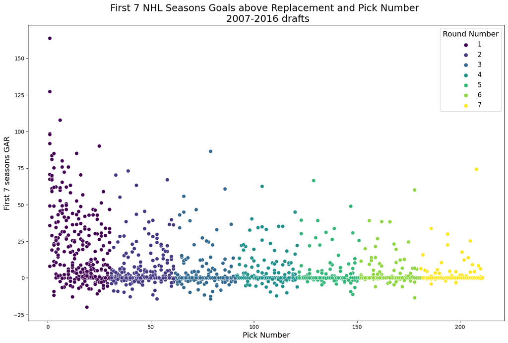

```python
plt.figure(figsize=(16, 10))  # Adjust the figure size
sns.scatterplot(data=selected_columns_df, x='overallPickNumber', y='GAR', hue='roundNumber', palette='viridis', s=50)  # Increase the point size with the 's' parameter

plt.title('First 7 NHL Seasons Goals above Replacement and Pick Number \n 2007-2016 drafts', fontsize=18)  # Increase the title font size
plt.xlabel('Pick Number', fontsize=14)  # Increase the x-axis label font size
plt.ylabel('First 7 seasons GAR', fontsize=14)  # Increase the y-axis label font size

# Increase the legend font size
plt.legend(title='Round Number', title_fontsize=14, fontsize=12)

plt.show()
```

Now we get to the interesting part: the results. The intuition that earlier picks are worth more looks accurate. A few players have negative value: that means that they have performed worse than a replacement-level player. There's a lot of players at or around 0 GAR, especially in the later rounds.This is normal as most players drafted never even make it to the NHL, it is quite hard to break through in the most competitive and skilled league in the world.

I used a simple generalized additive model (GAM) to smoothen the curve and get estimates for the value of each pick at a specific draft slot.

```python
from pygam import LinearGAM, s


# Remove rows with NaN values in 'overallPickNumber' and 'GAR' columns
clean_data = selected_columns_df.dropna(subset=['overallPickNumber', 'GAR'])

# Extract 'overallPickNumber' and 'GAR' as NumPy arrays
X = clean_data['overallPickNumber'].to_numpy()
y = clean_data['GAR'].to_numpy()


# Applying GAM

gam = LinearGAM(s(0)).fit(X, y)

unique_pick_numbers = np.unique(X)
predicted_gar_values = gam.predict(unique_pick_numbers)
```

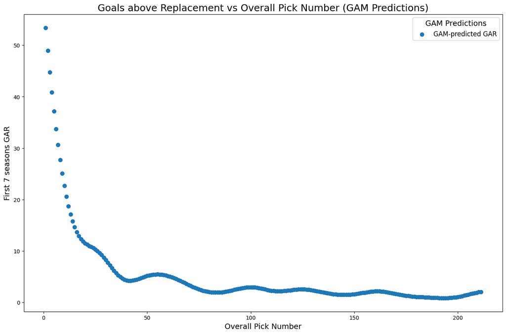

```python
plt.figure(figsize=(16, 10))

# Plot the GAM-predicted points
plt.scatter(unique_pick_numbers, predicted_gar_values, s=50, label='GAM-predicted GAR')

plt.title('Goals above Replacement vs Overall Pick Number (GAM Predictions)', fontsize=18)
plt.xlabel('Overall Pick Number', fontsize=14)
plt.ylabel('First 7 seasons GAR', fontsize=14)
plt.legend(title='GAM Predictions', title_fontsize=14, fontsize=12)
plt.show()
```

The above graph is very interesting: it shows us that the first 10 or so picks (even more in the top 3) are very valuable, and the drop off is quick after, as the value creeps towards zero in later rounds. I thought this did a decent job for a first attempt, however I wanted to represent the fact that the first two picks are even more valuable than other first round picks. In recent years, we've seen superstars Connor Mcdavid, John tavares, Auston matthews and Sydney Crosby drafted at the top of the draft. These players were (and are still) considered some of the very best in the NHL.

```python
first_pick_dummy = (X == 1).astype(int)
second_pick_dummy = (X == 2).astype(int)

X_augmented = np.column_stack((X, first_pick_dummy, second_pick_dummy))

gam_augmented = LinearGAM(s(0) + s(1) + s(2)).fit(X_augmented, y)


unique_first_pick_dummy = (unique_pick_numbers == 1).astype(int)
unique_second_pick_dummy = (unique_pick_numbers == 2).astype(int)

# Stack unique_pick_numbers and dummy variables
unique_pick_numbers_augmented = np.column_stack((unique_pick_numbers, unique_first_pick_dummy, unique_second_pick_dummy))

# Predict GAR values
predicted_gar_values_augmented = gam_augmented.predict(unique_pick_numbers_augmented)
```

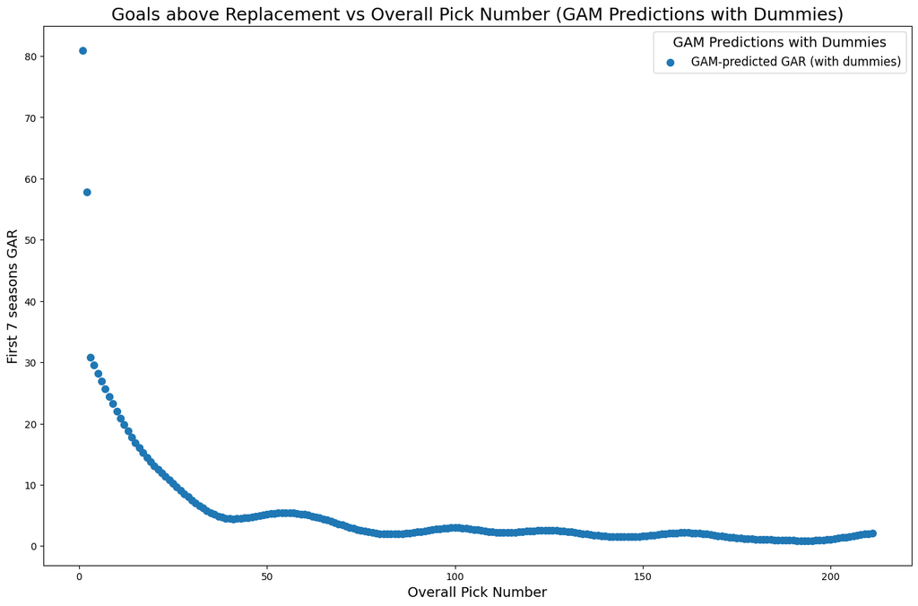

```python
plt.figure(figsize=(16, 10))

# Plot the GAM-predicted points with the augmented model
plt.scatter(unique_pick_numbers, predicted_gar_values_augmented, s=50, label='GAM-predicted GAR (with dummies)')

plt.title('Goals above Replacement vs Overall Pick Number (GAM Predictions with Dummies)', fontsize=18)
plt.xlabel('Overall Pick Number', fontsize=14)
plt.ylabel('First 7 seasons GAR', fontsize=14)
plt.legend(title='GAM Predictions with Dummies', title_fontsize=14, fontsize=12)
plt.show()
```

We can see that the first 2 picks are now much more valuable than the others. the drop off happens as quickly as the third pick overall.

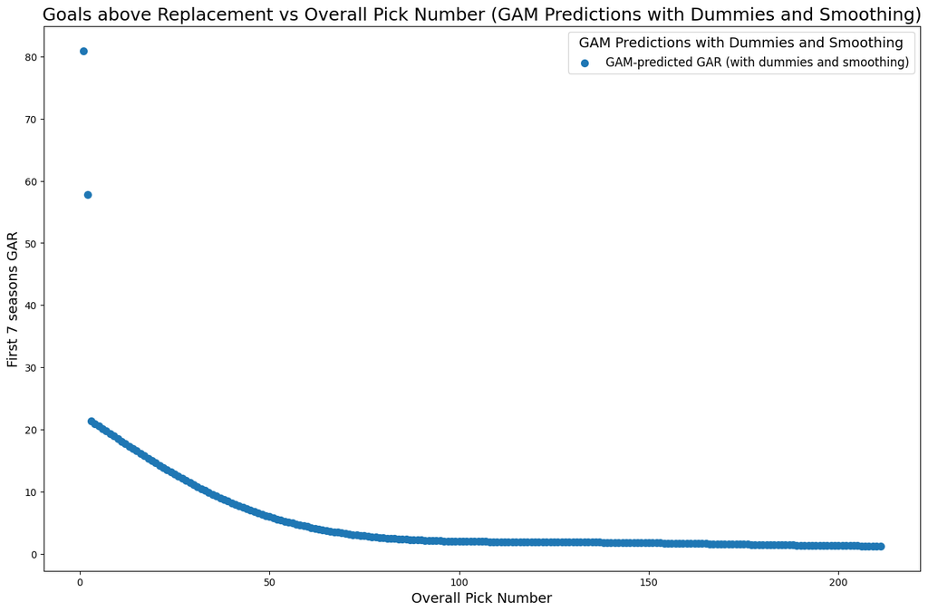

```python
gam_augmented_smooth = LinearGAM(s(0, lam=1000) + s(1, lam=1000) + s(2, lam=1000)).fit(X_augmented, y)
predicted_gar_values_augmented_smooth = gam_augmented_smooth.predict(unique_pick_numbers_augmented)
plt.figure(figsize=(16, 10))

# Plot the GAM-predicted points with the augmented and smoothed model
plt.scatter(unique_pick_numbers, predicted_gar_values_augmented_smooth, s=50, label='GAM-predicted GAR (with dummies and smoothing)')

plt.title('Goals above Replacement vs Overall Pick Number (GAM Predictions with Dummies and Smoothing)', fontsize=18)
plt.xlabel('Overall Pick Number', fontsize=14)
plt.ylabel('First 7 seasons GAR', fontsize=14)
plt.legend(title='GAM Predictions with Dummies and Smoothing', title_fontsize=14, fontsize=12)
plt.show()
```

I did further smoothing so that the curve would look nicer. This shows the very clear distinction between picks 1 and 2, and all 210 or so other picks.

```python
unique_pick_numbers_df = pd.DataFrame({'overallPickNumber': unique_pick_numbers,
                                       'predicted_GAR': predicted_gar_values_augmented_smooth})
unique_pick_numbers_df = unique_pick_numbers_df.merge(selected_columns_df[['overallPickNumber', 'roundNumber']].drop_duplicates(), on='overallPickNumber')
```

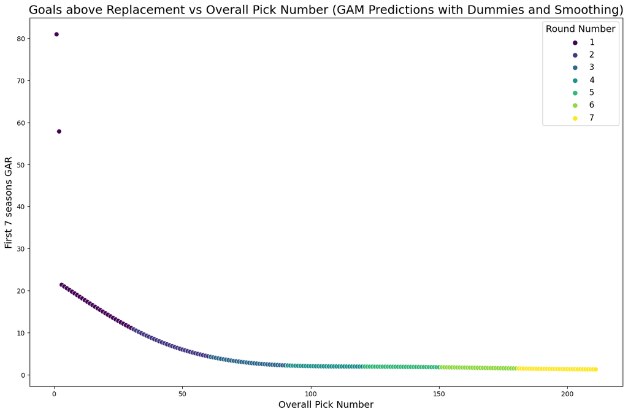

```python
plt.figure(figsize=(16, 10))

sns.scatterplot(data=unique_pick_numbers_df, x='overallPickNumber', y='predicted_GAR', hue='roundNumber', palette='viridis', s=50)

plt.title('Goals above Replacement vs Overall Pick Number (GAM Predictions with Dummies and Smoothing)', fontsize=18)
plt.xlabel('Overall Pick Number', fontsize=14)
plt.ylabel('First 7 seasons GAR', fontsize=14)
plt.legend(title='Round Number', title_fontsize=14, fontsize=12)
plt.show()
```

I've color coded the draft's rounds in the above graph.

This confirms our intuition that earlier picks are much more valuable. I also wanted to use this data to answer the following question: are teams overestimating the value of a players height and weight? NHL teams frequently go on and on about size (You can't teach size!!) and frequently draft them very high in the draft, sometimes despite their lack of high-end skills. Would teams be better off staying away from the taller players in favor of the shorter players? Let's find out!

```python
unique_pick_numbers_df
```

|  | overallPickNumber | predicted_GAR | roundNumber |
| --- | --- | --- | --- |
| 0 | 1 | 80.950000 | 1 |
| 1 | 2 | 57.840000 | 1 |
| 2 | 3 | 21.354732 | 1 |
| 3 | 4 | 20.944671 | 1 |
| 4 | 5 | 20.535265 | 1 |
| ... | ... | ... | ... |
| 211 | 207 | 1.247660 | 7 |
| 212 | 208 | 1.242612 | 7 |
| 213 | 209 | 1.237619 | 7 |
| 214 | 210 | 1.232669 | 7 |
| 215 | 211 | 1.227747 | 7 |

216 rows × 3 columns

```python
merged_df_with_predictions = merged_df.merge(unique_pick_numbers_df[['overallPickNumber', 'predicted_GAR']], on='overallPickNumber', how='left')
merged_df_with_predictions['GAR'] = merged_df_with_predictions['GAR'].fillna(0)
merged_df_with_predictions['GAR_diff'] = merged_df_with_predictions['GAR'] - merged_df_with_predictions['predicted_GAR']
merged_df_with_predictions['Hit_or_Miss'] = (merged_df_with_predictions['GAR_diff'] > 0).astype(int)
merged_df_with_predictions
```

|  | id | ageInDays | ageInDaysForYear | ageInYears | amateurClubName | amateurLeague | birthDate | birthPlace | countryCode | csPlayerId | ... | Draw_GAR | Off_GAR | Def_GAR | Pens_GAR | GAR | WAR | SPAR | predicted_GAR | GAR_diff | Hit_or_Miss |
| --- | --- | --- | --- | --- | --- | --- | --- | --- | --- | --- | --- | --- | --- | --- | --- | --- | --- | --- | --- | --- | --- |
| 0 | 2110 | 6789.0 | 215.0 | 18.0 | London | OHL | 1988-11-19 | Buffalo, NY USA | USA | 12166.0 | ... | 11.4 | 76.3 | -4.8 | 20.2 | 91.7 | 16.7 | 31.6 | 80.950000 | 10.750000 | 1 |
| 1 | 2109 | 6623.0 | 49.0 | 18.0 | USA U-18 | USDP | 1989-05-04 | Middletown, NJ USA | USA | 25080.0 | ... | -1.3 | 33.4 | -13.1 | -1.3 | 19.0 | 3.4 | 6.5 | 57.840000 | -38.840000 | 0 |
| 2 | 2108 | 6521.0 | 312.0 | 17.0 | Burnaby | BCHL | 1989-08-14 | New Westminster, BC CAN | CAN | 24887.0 | ... | 0.3 | 22.4 | -15.1 | 3.9 | 11.2 | 2.1 | 4.0 | 21.354732 | -10.154732 | 0 |
| 3 | 2107 | 6708.0 | 134.0 | 18.0 | Seattle | WHL | 1989-02-08 | Calgary, AB CAN | CAN | 10664.0 | ... | -0.5 | 6.9 | 2.7 | 0.7 | 10.4 | 1.9 | 3.6 | 20.944671 | -10.544671 | 0 |
| 4 | 2106 | 6845.0 | 271.0 | 18.0 | Calgary | WHL | 1988-09-24 | Burnaby, BC CAN | CAN | 270.0 | ... | -2.1 | 0.4 | 17.6 | 5.6 | 23.6 | 4.3 | 8.0 | 20.535265 | 3.064735 | 1 |
| ... | ... | ... | ... | ... | ... | ... | ... | ... | ... | ... | ... | ... | ... | ... | ... | ... | ... | ... | ... | ... | ... |
| 1936 | 16074 | 6733.0 | 159.0 | 18.0 | WBS Knights | NAHL | 1998-01-18 | Togliatti, Russia | RUS | 65765.0 | ... | NaN | NaN | NaN | NaN | 0.0 | NaN | NaN | 1.247660 | -1.247660 | 0 |
| 1937 | 16075 | 7304.0 | 365.0 | 19.0 | Waterloo | USHL | 1996-06-26 | Chester, PA USA | USA | 63268.0 | ... | NaN | NaN | NaN | NaN | 0.0 | NaN | NaN | 1.242612 | -1.242612 | 0 |
| 1938 | 16076 | 6527.0 | 318.0 | 17.0 | Rodovre | DENMARK | 1998-08-12 | Rodovre, Denmark | DNK | 67258.0 | ... | NaN | NaN | NaN | NaN | 0.0 | NaN | NaN | 1.237619 | -1.237619 | 0 |
| 1939 | 16077 | 6553.0 | 344.0 | 17.0 | Malmo Jr. | SWEDEN | 1998-07-17 | Frederikshavn, Denmark | DNK | 66972.0 | ... | 0.1 | -0.7 | 0.4 | -0.1 | -0.4 | -0.1 | -0.1 | 1.232669 | -1.632669 | 0 |
| 1940 | 16078 | 6652.0 | 77.0 | 18.0 | Litvinov Jr. | CZREP-JR. | 1998-04-09 | Litvinov, Czech Republic | CZE | 71578.0 | ... | NaN | NaN | NaN | NaN | 0.0 | NaN | NaN | 1.227747 | -1.227747 | 0 |

1941 rows × 52 columns

```python
merged_df_with_predictions.columns
```

```
Index(['id', 'ageInDays', 'ageInDaysForYear', 'ageInYears', 'amateurClubName',
       'amateurLeague', 'birthDate', 'birthPlace', 'countryCode', 'csPlayerId',
       'draftDate', 'draftMasterId', 'draftYear', 'draftedByTeamId',
       'firstName', 'height', 'lastName', 'notes', 'overallPickNumber',
       'pickInRound', 'playerId', 'playerName', 'position', 'removedOutright',
       'removedOutrightWhy', 'roundNumber', 'shootsCatches',
       'supplementalDraft', 'teamPickHistory', 'triCode', 'weight', 'Player',
       'Season', 'Team', 'Position', 'GP', 'TOI_All', 'EVO_GAR', 'EVD_GAR',
       'PPO_GAR', 'SHD_GAR', 'Take_GAR', 'Draw_GAR', 'Off_GAR', 'Def_GAR',
       'Pens_GAR', 'GAR', 'WAR', 'SPAR', 'predicted_GAR', 'GAR_diff',
       'Hit_or_Miss'],
      dtype='object')
```

The average player is somewhere around 6 FT (72 inches or 183cm) tall. I considered anyone above 6ft tall, and anyone below that short. I also used their weight to calculate BMI.

```python
final_df = merged_df_with_predictions[['playerName', 'overallPickNumber', 'triCode', 'height', 'weight', 'Position', 'draftYear', 'GAR', 'predicted_GAR', 'GAR_diff', 'Hit_or_Miss']]
final_df['height_diff'] = final_df['height'] - 72
# Convert weight from pounds to kilograms
final_df['weight_kg'] = final_df['weight'] * 0.453592

# Convert height from inches to meters
final_df['height_m'] = final_df['height'] * 0.0254

# Calculate BMI
final_df['BMI'] = final_df['weight_kg'] / (final_df['height_m'] ** 2)
final_df['bmi_diff'] = final_df['BMI'] - 25


# Create weight bins:

final_df['weight_bins'] = pd.cut(final_df['weight'], bins=range(130, 260, 10), include_lowest=True)


final_df
```

[output not shown]

|  | playerName | overallPickNumber | triCode | height | weight | Position | draftYear | GAR | predicted_GAR | GAR_diff | Hit_or_Miss | height_diff | weight_kg | height_m | BMI | bmi_diff | weight_bins |
| --- | --- | --- | --- | --- | --- | --- | --- | --- | --- | --- | --- | --- | --- | --- | --- | --- | --- |
| 0 | patrick kane | 1 | CHI | 70.0 | 178.0 | R | 2007 | 91.7 | 80.950000 | 10.750000 | 1 | -2.0 | 80.739376 | 1.7780 | 25.540058 | 0.540058 | (170.0, 180.0] |
| 1 | james van riemsdyk | 2 | PHI | 75.0 | 200.0 | L | 2007 | 19.0 | 57.840000 | -38.840000 | 0 | 3.0 | 90.718400 | 1.9050 | 24.998009 | -0.001991 | (190.0, 200.0] |
| 2 | kyle turris | 3 | PHX | 73.0 | 185.0 | C | 2007 | 11.2 | 21.354732 | -10.154732 | 0 | 1.0 | 83.914520 | 1.8542 | 24.407537 | -0.592463 | (180.0, 190.0] |
| 3 | thomas hickey | 4 | LAK | 71.0 | 184.0 | D | 2007 | 10.4 | 20.944671 | -10.544671 | 0 | -1.0 | 83.460928 | 1.8034 | 25.662507 | 0.662507 | (180.0, 190.0] |
| 4 | karl alzner | 5 | WSH | 75.0 | 206.0 | D | 2007 | 23.6 | 20.535265 | 3.064735 | 1 | 3.0 | 93.439952 | 1.9050 | 25.747949 | 0.747949 | (200.0, 210.0] |
| ... | ... | ... | ... | ... | ... | ... | ... | ... | ... | ... | ... | ... | ... | ... | ... | ... | ... |
| 1936 | dmitriy zaitsev | 207 | WSH | 72.0 | 184.0 | NaN | 2016 | 0.0 | 1.247660 | -1.247660 | 0 | 0.0 | 83.460928 | 1.8288 | 24.954610 | -0.045390 | (180.0, 190.0] |
| 1937 | ryan lohin | 208 | TBL | 71.0 | 193.0 | NaN | 2016 | 0.0 | 1.242612 | -1.242612 | 0 | -1.0 | 87.543256 | 1.8034 | 26.917738 | 1.917738 | (190.0, 200.0] |
| 1938 | nikolaj krag christensen | 209 | STL | 75.0 | 201.0 | NaN | 2016 | 0.0 | 1.237619 | -1.237619 | 0 | 3.0 | 91.171992 | 1.9050 | 25.122999 | 0.122999 | (200.0, 210.0] |
| 1939 | joachim blichfeld | 210 | SJS | 74.0 | 176.0 | L | 2016 | -0.4 | 1.232669 | -1.632669 | 0 | 2.0 | 79.832192 | 1.8796 | 22.596812 | -2.403188 | (170.0, 180.0] |
| 1940 | filip helt | 211 | STL | 73.0 | 176.0 | NaN | 2016 | 0.0 | 1.227747 | -1.227747 | 0 | 1.0 | 79.832192 | 1.8542 | 23.220144 | -1.779856 | (170.0, 180.0] |

1941 rows × 17 columns

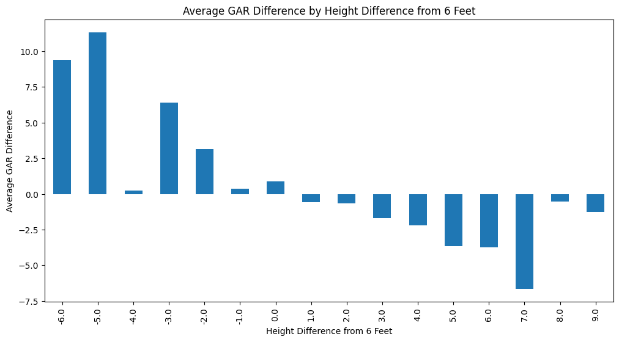

```python
height_diff_gar_diff = final_df.groupby('height_diff')['GAR_diff'].mean()
plt.figure(figsize=(12, 6))
height_diff_gar_diff.plot(kind='bar')
plt.xlabel('Height Difference from 6 Feet')
plt.ylabel('Average GAR Difference')
plt.title('Average GAR Difference by Height Difference from 6 Feet')
plt.show()
```

The above graph is extremely interesting. Short players tend to outperform their expected draft slot value more than similarly tall players. It does look like teams tend to reach in the draft for size, generally preferring taller players.

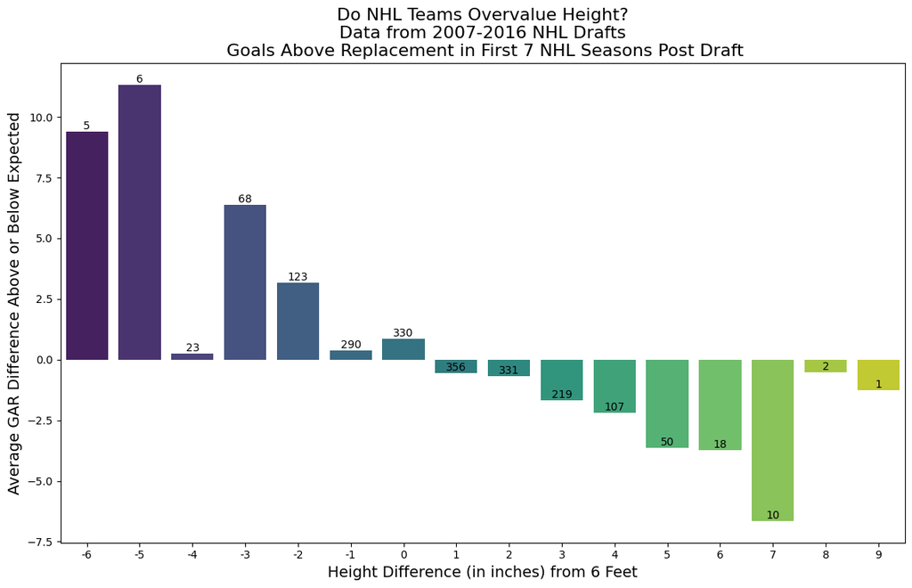

```python
# Calculate the sample size for each 'height_diff'
height_diff_count = final_df['height_diff'].value_counts()

# Create a bar plot of the average 'GAR_diff' for each 'height_diff'
plt.figure(figsize=(14, 8))
barplot = sns.barplot(x=height_diff_gar_diff.index, y=height_diff_gar_diff.values, palette='viridis')
plt.xlabel('Height Difference (in inches) from 6 Feet',fontsize=14)
plt.ylabel('Average GAR Difference Above or Below Expected',fontsize=14)
plt.title('Do NHL Teams Overvalue Height?\n Data from 2007-2016 NHL Drafts \n Goals Above Replacement in First 7 NHL Seasons Post Draft' ,fontsize=16)

# Set xticklabels based on the original 'height_diff' values
barplot.set_xticklabels(height_diff_gar_diff.index.astype(int))

# Add sample size labels above each bar
for i, p in enumerate(barplot.patches):
    height = p.get_height()
    barplot.text(p.get_x() + p.get_width() / 2., height, height_diff_count.loc[height_diff_gar_diff.index[i]],
                 ha='center', va='bottom')

plt.show()
```

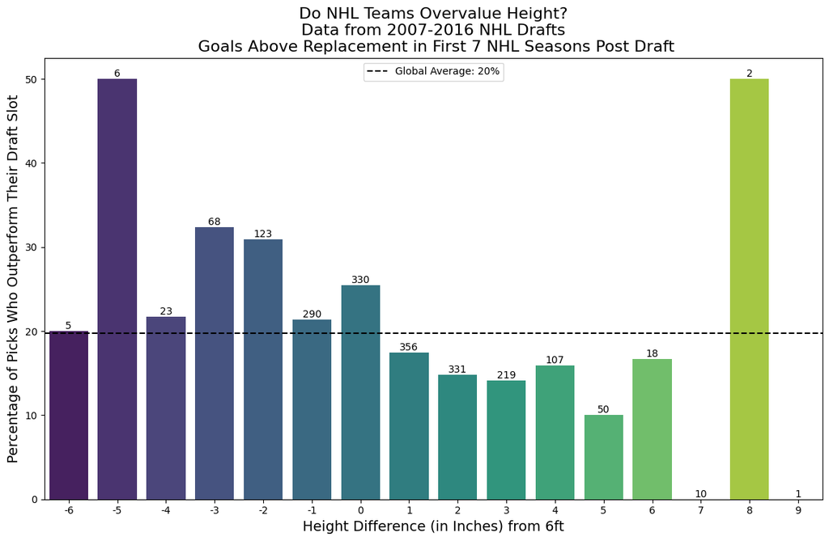

```python
# Group by 'height_diff' and calculate the mean 'Hit_or_Miss'
height_diff_hit_percent = final_df.groupby('height_diff')['Hit_or_Miss'].mean() * 100

# Calculate the global average Hit percentage
global_avg_hit_percent = final_df['Hit_or_Miss'].mean() * 100

# Create a bar plot of the percentage of Hits for each 'height_diff'
plt.figure(figsize=(14, 8))
barplot = sns.barplot(x=height_diff_hit_percent.index, y=height_diff_hit_percent.values, palette='viridis')
plt.xlabel('Height Difference (in Inches) from 6ft',fontsize=14)
plt.ylabel('Percentage of Picks Who Outperform Their Draft Slot',fontsize=14)
plt.title('Do NHL Teams Overvalue Height?\n Data from 2007-2016 NHL Drafts \n Goals Above Replacement in First 7 NHL Seasons Post Draft' ,fontsize=16)

# Set xticklabels based on the original 'height_diff' values
barplot.set_xticklabels(height_diff_hit_percent.index.astype(int))

# Add sample size labels above each bar
for i, p in enumerate(barplot.patches):
    height = p.get_height()
    barplot.text(p.get_x() + p.get_width() / 2., height, f"{height_diff_count.loc[height_diff_hit_percent.index[i]]}",
                 ha='center', va='bottom')

# Add a horizontal line to show the global average Hit percentage
plt.axhline(global_avg_hit_percent, linestyle='--', color='black', label=f'Global Average: {global_avg_hit_percent:.0f}%')
plt.legend()

plt.show()
```

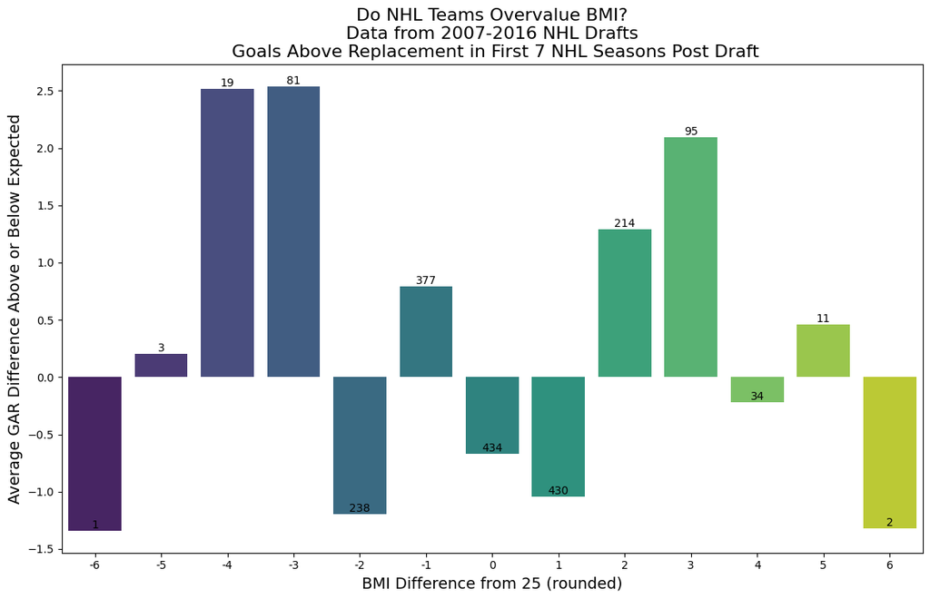

```python
# Round the 'bmi_diff' to the nearest integer
final_df = final_df.dropna(subset=['bmi_diff'])
final_df['bmi_diff_rounded'] = final_df['bmi_diff'].round().astype(int)

# Calculate the sample size for each 'bmi_diff_rounded'
bmi_diff_count = final_df['bmi_diff_rounded'].value_counts()

# Calculate the average 'GAR_diff' for each 'bmi_diff_rounded'
bmi_diff_gar_diff = final_df.groupby('bmi_diff_rounded')['GAR_diff'].mean()

# Create a bar plot of the average 'GAR_diff' for each 'bmi_diff_rounded'
plt.figure(figsize=(14, 8))
barplot = sns.barplot(x=bmi_diff_gar_diff.index, y=bmi_diff_gar_diff.values, palette='viridis')
plt.xlabel('BMI Difference from 25 (rounded)', fontsize=14)
plt.ylabel('Average GAR Difference Above or Below Expected', fontsize=14)
plt.title('Do NHL Teams Overvalue BMI?\n Data from 2007-2016 NHL Drafts \n Goals Above Replacement in First 7 NHL Seasons Post Draft', fontsize=16)

# Set xticklabels based on the original 'bmi_diff_rounded' values
barplot.set_xticklabels(bmi_diff_gar_diff.index.astype(int))

# Add sample size labels above each bar
for i, p in enumerate(barplot.patches):
    height = p.get_height()
    barplot.text(p.get_x() + p.get_width() / 2., height, bmi_diff_count.loc[bmi_diff_gar_diff.index[i]],
                 ha='center', va='bottom')

plt.show()
```

I tried to look at BMI (and weight), however I found inconclusive evidence

```python
final_df['triCode'] = final_df['triCode'].replace({'PHX': 'ARI', 'ATL': 'WPG'})

final_df['triCode'].unique()
```

```
array(['CHI', 'PHI', 'ARI', 'LAK', 'WSH', 'EDM', 'CBJ', 'BOS', 'SJS',
       'FLA', 'CAR', 'MTL', 'STL', 'COL', 'MIN', 'NYR', 'ANA', 'PIT',
       'NSH', 'CGY', 'VAN', 'DET', 'OTT', 'BUF', 'TBL', 'DAL', 'NJD',
       'NYI', 'WPG', 'TOR'], dtype=object)
```

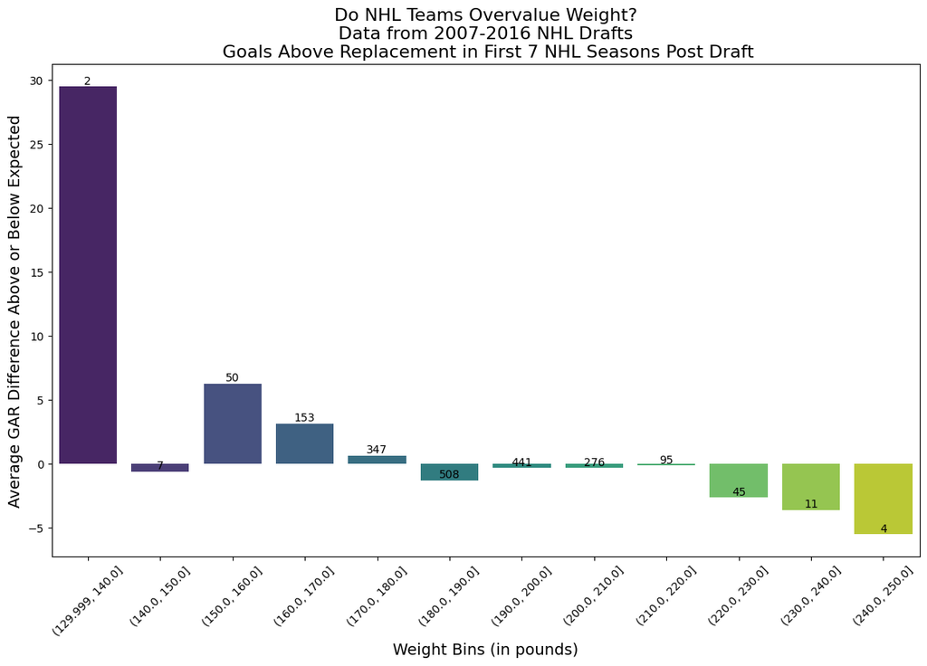

```python
# Calculate the sample size for each 'weight_bins'
weight_bins_count = final_df['weight_bins'].value_counts()

# Calculate the average 'GAR_diff' for each 'weight_bins'
weight_bins_gar_diff = final_df.groupby('weight_bins')['GAR_diff'].mean()

# Create a bar plot of the average 'GAR_diff' for each 'weight_bins'
plt.figure(figsize=(14, 8))
barplot = sns.barplot(x=weight_bins_gar_diff.index, y=weight_bins_gar_diff.values, palette='viridis')
plt.xlabel('Weight Bins (in pounds)', fontsize=14)
plt.ylabel('Average GAR Difference Above or Below Expected', fontsize=14)
plt.title('Do NHL Teams Overvalue Weight?\n Data from 2007-2016 NHL Drafts \n Goals Above Replacement in First 7 NHL Seasons Post Draft', fontsize=16)

# Set xticklabels based on the original 'weight_bins' values
barplot.set_xticklabels(weight_bins_gar_diff.index, rotation=45)

# Add sample size labels above each bar
for i, p in enumerate(barplot.patches):
    height = p.get_height()
    barplot.text(p.get_x() + p.get_width() / 2., height, weight_bins_count.loc[weight_bins_gar_diff.index[i]],
                 ha='center', va='bottom')

plt.show()
```

```python
# Filter the DataFrame to show players with a weight between 130 and 140 pounds
lightweight_players = final_df[(final_df['weight'] > 150) & (final_df['weight'] <= 160)]

# Display the 'playerName' column of the filtered DataFrame
print(lightweight_players['playerName'])
```

```
117            austin smith
218             tyler ennis
279         david warsofsky
360           matias sointu
381         patrick johnson
442           brandon pirri
452            reilly smith
548           brandon kozun
628          calle jarnkrok
666        joakim nordstrom
681         marcus sorensen
691            james mullin
702          john klingberg
764            ben marshall
806          rocco grimaldi
```

[output cut: 36 more lines]

Finally, I had a look at which teams outperformed their draft slot the most. Over the 2007-2016 drafts, which teams were good drafters? Which teams extracted the most value out of the picks they had available to them?

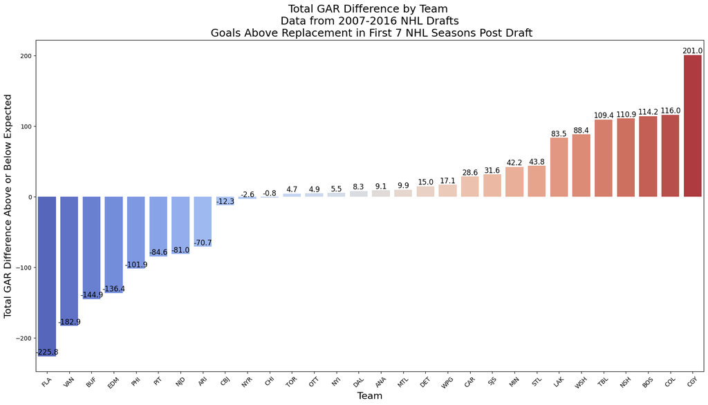

```python
# Calculate the total sum of 'GAR_diff' for each 'triCode'
triCode_gar_diff_sum = final_df.groupby('triCode')['GAR_diff'].sum()

# Sort the values in ascending order
triCode_gar_diff_sum_sorted = triCode_gar_diff_sum.sort_values()

plt.figure(figsize=(20, 10))
barplot = sns.barplot(x=triCode_gar_diff_sum_sorted.index, y=triCode_gar_diff_sum_sorted.values, palette='coolwarm')
plt.xlabel('Team', fontsize=16)
plt.ylabel('Total GAR Difference Above or Below Expected', fontsize=16)
plt.title('Total GAR Difference by Team \n Data from 2007-2016 NHL Drafts \n Goals Above Replacement in First 7 NHL Seasons Post Draft', fontsize=18)
plt.xticks(rotation=45)


# Add the values above each bar
for i, p in enumerate(barplot.patches):
    height = p.get_height()
    barplot.text(p.get_x() + p.get_width() / 2., height, round(triCode_gar_diff_sum_sorted.values[i], 1),
                 ha='center', va='bottom', fontsize=12, color='black')

plt.show()
```

The calgary flames were the best drafters over the 2007-2016 drafts. Other top drafters include Colorado, Tampa Bay, and Boston: all teams that have been very good over the past decade. The worst drafters were the Florida Panthers, Vancouver Canucks, and Buffalo Sbres. The edmonton oilers also underperformed their draft slot, given how much good draft picks they had available to them over the years.

You can see below which players contribued the most GAR to the Calgary Flames.

```python
# Filter the final_df for rows where triCode is 'CGY'
cgy_players = final_df[final_df['triCode'] == 'CGY']

# Select the 'playerName' and 'GAR_diff' columns
cgy_players_gar_diff = cgy_players[['playerName', 'GAR_diff']]

# Sort the values by 'GAR_diff' in descending order
cgy_players_gar_diff_sorted = cgy_players_gar_diff.sort_values(by='GAR_diff', ascending=False)

# Display the sorted DataFrame
cgy_players_gar_diff_sorted
```

|  | playerName | GAR_diff |
| --- | --- | --- |
| 1748 | matthew tkachuk | 87.573314 |
| 873 | johnny gaudreau | 60.541978 |
| 1804 | adam fox | 52.074947 |
| 1705 | andrew mangiapane | 36.710048 |
| 297 | tj brodie | 33.292529 |
| 1167 | sean monahan | 32.573314 |
| 1600 | rasmus andersson | 24.300096 |
| 23 | mikael backlund | 16.873113 |
| 1795 | dillon dube | 10.689515 |
| 1607 | oliver kylington | 10.264193 |
| 1065 | brett kulak | 10.149387 |
| 786 | sven baertschi | 7.995890 |
| 704 | micheal ferland | 3.056812 |
| 264 | lance bouma | 2.735265 |
| 571 | gaelan patterson | -1.279895 |
| 373 | alexander deilert | -1.297883 |
| 1731 | riley bruce | -1.310790 |
| 756 | patrick holland | -1.331627 |
| 1335 | rushan rafikov | -1.379007 |
| 171 | c.j. severyn | -1.387691 |
| 1140 | matthew deblouw | -1.387691 |
| 1915 | stepan falkovsky | -1.387691 |
| 1523 | austin carroll | -1.405730 |
| 1517 | adam ollas mattsson | -1.495170 |
| 346 | ryley grantham | -1.569056 |
| 1897 | matthew phillips | -1.589952 |
| 1121 | coda gordon | -1.600273 |
| 1308 | tim harrison | -1.677662 |
| 1888 | eetu tuulola | -1.686579 |
| 131 | mickey renaud | -1.786858 |
| 517 | spencer bennett | -1.799636 |
| 1678 | pavel karnaukhov | -1.828289 |
| 1286 | eric roy | -1.833445 |
| 1861 | mitchell mattson | -1.871579 |
| 1084 | ryan culkin | -1.878133 |
| 489 | henrik bjorklund | -1.918406 |
| 682 | bill arnold | -1.932250 |
| 291 | nicholas larson | -1.932250 |
| 678 | john ramage | -1.966176 |
| 816 | markus granlund | -1.974977 |
| 1832 | linus lindstrom | -2.049619 |
| 457 | ryan howse | -2.923893 |
| 650 | joey leach | -2.997628 |
| 641 | max reinhart | -3.043033 |
| 66 | john negrin | -3.241894 |
| 1224 | keegan kanzig | -3.522811 |
| 1414 | brandon hickey | -3.843033 |
| 1346 | john gilmour | -4.897883 |
| 1406 | hunter smith | -5.230959 |
| 827 | tyler wotherspoon | -6.158714 |
| 237 | mitch wahl | -6.336421 |
| 1008 | patrick sieloff | -7.673261 |
| 989 | mark jankowski | -8.720169 |
| 1189 | morgan klimchuk | -11.740996 |
| 217 | greg nemisz | -11.772231 |
| 107 | keith aulie | -12.101178 |
| 1183 | emile poirier | -13.851120 |
| 408 | tim erixon | -16.886605 |
| 1360 | sam bennett | -18.344671 |

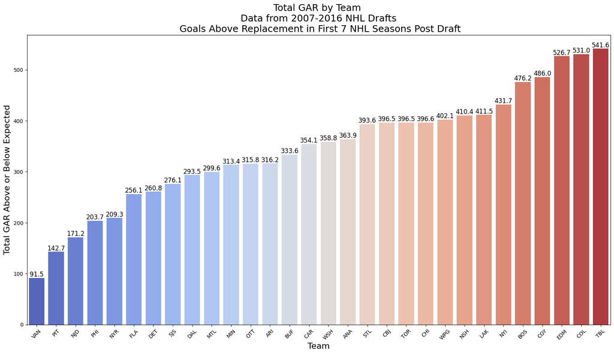

```python
# Calculate the total sum of 'GAR' for each 'triCode'
triCode_gar_sum = final_df.groupby('triCode')['GAR'].sum()

# Sort the values in ascending order
triCode_gar_sum_sorted = triCode_gar_sum.sort_values()

plt.figure(figsize=(20, 10))
barplot = sns.barplot(x=triCode_gar_sum_sorted.index, y=triCode_gar_sum_sorted.values, palette='coolwarm')
plt.xlabel('Team', fontsize=16)
plt.ylabel('Total GAR Above or Below Expected', fontsize=16)
plt.title('Total GAR by Team \n Data from 2007-2016 NHL Drafts \n Goals Above Replacement in First 7 NHL Seasons Post Draft', fontsize=18)
plt.xticks(rotation=45)

# Add the values above each bar
for i, p in enumerate(barplot.patches):
    height = p.get_height()
    barplot.text(p.get_x() + p.get_width() / 2., height, round(triCode_gar_sum_sorted.values[i], 1),
                 ha='center', va='bottom', fontsize=12, color='black')

plt.show()
```